# Chapter 9 Examples

Author

THM

## Box 9.4 | Balanced design (Quinn and Keough 2002)

Keough and Quinn (1998) examined the effects of season (winter/spring and summer/autumn) and adult density (8, 15, 30 and 45 animals per 225 $cm^2$ enclosure) on the production of egg masses by intertidal pulmonate limpets (Gastropoda: *Siphonaria diemenensis*). There were three replicate enclosures per treatment combination and the response variable was the number of egg masses per limpet in each enclosure.

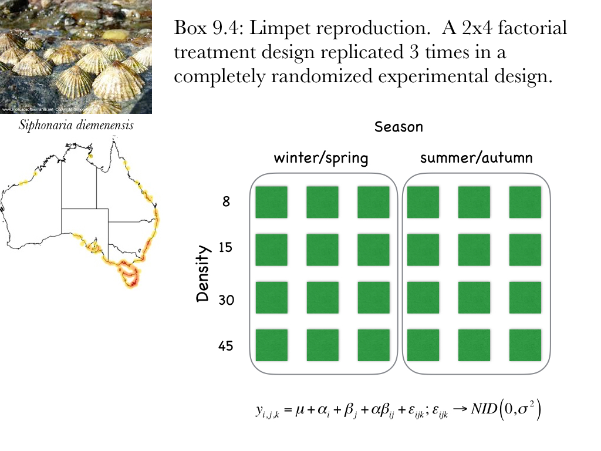

Figure 1: Experimental organism, location, and diagram of experimental design for Box 9.4.

Let’s do the ANOVA

Table 1: ANOVA summary for production of egg masses by intertidal pulmonate limpets (Gastropoda: *Siphonaria diemenensis*) (Keough and Quinn 1998).

|  | SS | df | F | P |
| --- | --- | --- | --- | --- |
| density | 5.28 | 3 | 9.67 | 0.001 |
| season | 3.25 | 1 | 17.84 | 0.001 |
| density:season | 0.16 | 3 | 0.30 | 0.824 |
| Residuals | 2.91 | 16 |  |  |

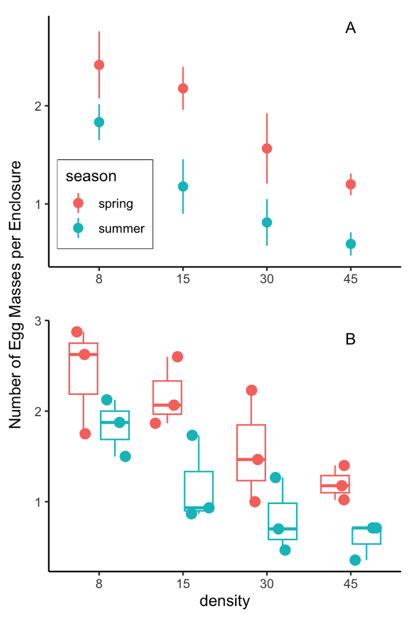

Figure 2: Number of egg masses ((A - means $\pm$ SE; B - medians and IQR) for *Siphonaria diemenensis* at two different seasons (winter/spring and summer/autumn) and four different adult densities.

# Unbalanced Design: Hall et al. (2000) example used in Table 9.15

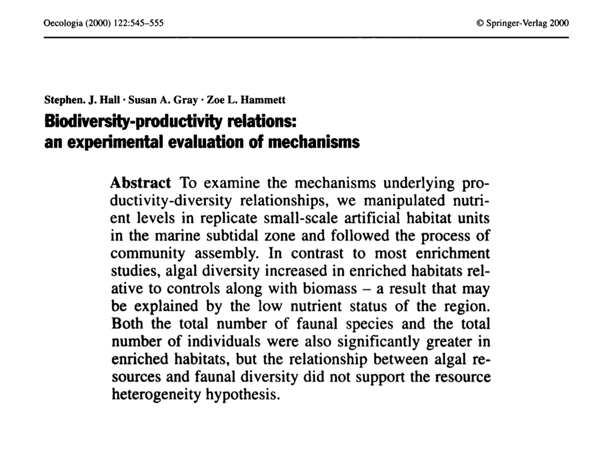

[figure not shown]

#### Remember:

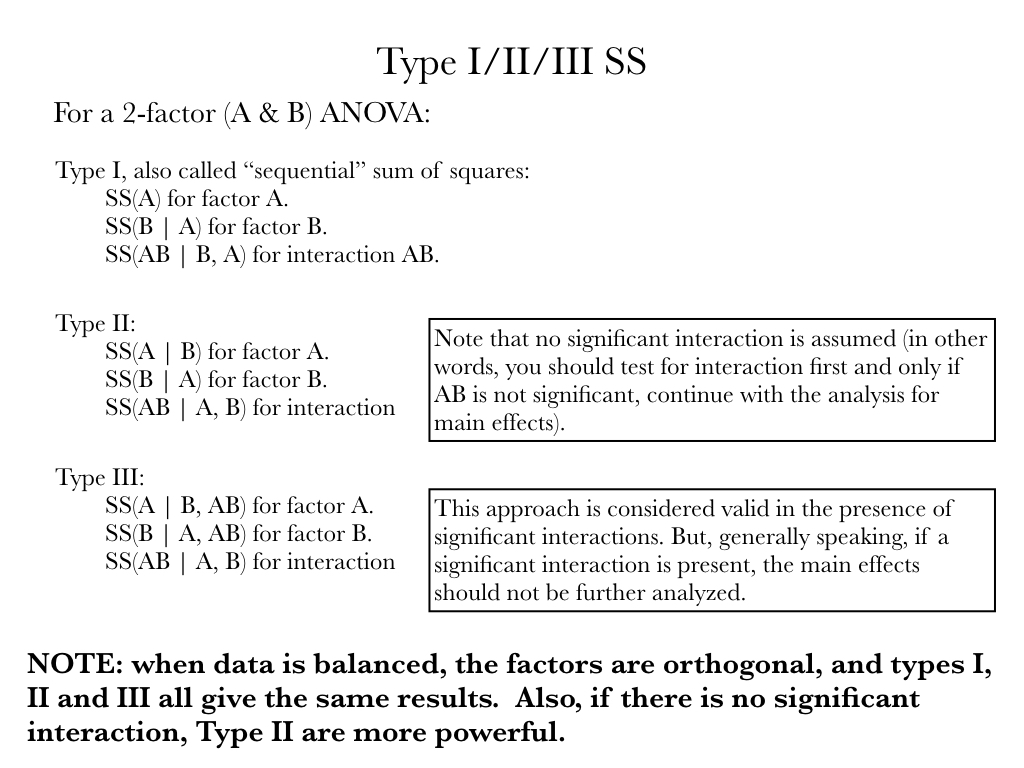

The default `anova()` function (R Core Team 2023) provided by `R` produces Type I, or sequential SS (Table 2). The Anova() function from the car package (Fox and Weisberg 2019) may produce Type II SS (Table 3) or Type III SS (Table 4).

Table 2: Type I SS using anova() (R Core Team 2023)

| Source | df | SS | MS | F | P |
| --- | --- | --- | --- | --- | --- |
| treat | 1 | 347.15 | 347.15 | 34.06 | <0.001 |
| time | 2 | 2884.34 | 1442.17 | 141.51 | <0.001 |
| treat:time | 2 | 131.91 | 65.96 | 6.47 | 0.006 |
| Residuals | 23 | 234.40 | 10.19 |  |  |

Table 3: Type II SS using Anova() from the car package (Fox and Weisberg 2019)

| Source | SS | df | F | P |
| --- | --- | --- | --- | --- |
| treat | 281.08 | 1 | 27.58 | <0.001 |
| time | 2884.34 | 2 | 141.51 | <0.001 |
| treat:time | 131.91 | 2 | 6.47 | 0.006 |
| Residuals | 234.40 | 23 |  |  |

Table 4: Type III SS using Anova() from the car package (Fox and Weisberg 2019).

| Source | SS | df | F | P |
| --- | --- | --- | --- | --- |
| (Intercept) | 11443.33 | 1 | 1122.85 | <0.001 |
| treat | 282.75 | 1 | 27.74 | <0.001 |
| time | 2869.27 | 2 | 140.77 | <0.001 |
| treat:time | 131.91 | 2 | 6.47 | 0.006 |
| Residuals | 234.40 | 23 |  |  |

Note that the interaction of treatment and time is significant (Table 4). What does that mean? Let’s look at an interaction plot to think about it (Figure 3). For a two-way factorial design, we can think of a significant interaction meaning that one factor alters the effect of the other factor. Here, notice that the distance between the two treatment levels changes depending on time.

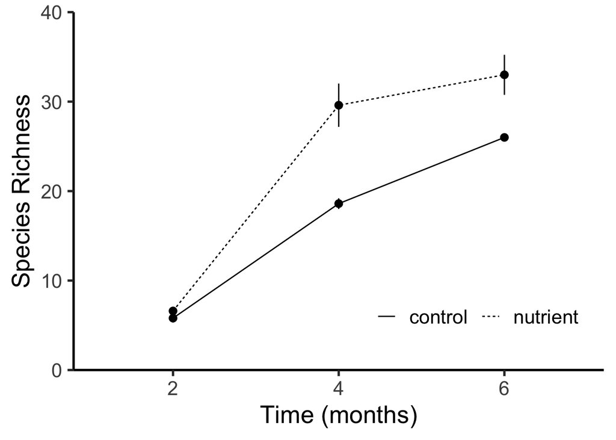

Figure 3: An *interaction plot* of species richness through time for the control and nutrient addition treatments (Hall et al. 2000).

## References

Fox, J., and S. Weisberg. 2019. [An r companion to applied regression](https://socialsciences.mcmaster.ca/jfox/Books/Companion/).

Hall, S. J., S. A. Gray, and Z. L. Hammett. 2000. Biodiversity-productivity relations: An experimental evaluation of mechanisms. Oecologia 122:545555.

Keough, M. J., and G. P. Quinn. 1998. [Effects of periodic disturbances from trampling on rocky intertidal algal beds](https://doi.org/10.2307/2641317). Ecological Applications 8:141–161.

Quinn, G. P., and M. J. Keough. 2002. Experimental design and data analysis for biologists. Cambridge.

R Core Team. 2023. [R: A language and environment for statistical computing](https://www.R-project.org/).